# My First R Markdown Report

Randi H Griffin

Dec 25, 2019

# Introduction

This report demonstrates R Markdown’s capabilities.

**Hint:** You need to replicate this report EXACTLY, except you should ignore **Hints** and replace the name and date in the YAML header.

**Hint:** There are 3 section header sizes used in this report. The Introduction is the largest header size.

**Hint:** Automatically generate a table of contents by specifying the following `output` settings in your YAML header:

```
output:
  html_document:
    toc: true
    toc_depth: 3
```

**Hint:** You can find the syntax to do everything in [the R Markdown reference guide](https://www.rstudio.com/wp-content/uploads/2015/03/rmarkdown-reference.pdf) that I mentioned in the Assignment!

## 1 Formatting text

This section demonstrates text formatting.

### 1.1 Basic in-line text formatting

[R Markdown](https://rmarkdown.rstudio.com/) uses the `knitr` R package under the hood. You can knit documents by pressing the **Knit** button in R Studio. *Amazing!*

**Hint:** Be sure the hyperlink you create actually works! The link above should send you to the home page for R Markdown.

**Hint:** The word ‘knitr’ above is formatted as in-line code. It doesn’t get run like a real code block. It is just a special way to highlight text.

### 1.2 Lists

Lists are a useful way to summarize important information.

You can create numbered lists:

1. Monday
2. Tuesday
3. Wednesday
4. Thursday
5. Friday
6. Saturday
7. Sunday

Or you can create bullet points:

- Banana
- Apple
  - Green apple
  - Red apple
- Pear

**Hint:** There must be a single space between your number/bullet and the text. For example, `* Banana` will work, but `*Banana` will not.

**Hint:** Indent *four spaces* to produce the second-level bullet points (Green apple and Red apple).

### 1.3 Block quotes

This is a good quote:

> All models are wrong, but some are useful. - George Box

## 2 Formatting code

### 2.1 Run visible code with output

```r
# Say hello
print('Hello World!')
```

```
## [1] "Hello World!"
```

```r
# A sum of two and two
x <- 2 + 2
x
```

```
## [1] 4
```

```r
# A sequence from 1 to 10
1:10
```

```
##  [1]  1  2  3  4  5  6  7  8  9 10
```

**Hint:** You can write all of the code in a single block and the multiple outputs automatically get split up.

### 2.2 Display code WITHOUT running it

```r
# Say hello
print('Hello World!')

# A sum of two and two
x <- 2 + 2
x

# A sequence from 1 to 10
1:10
```

**Hint:** You need `eval=FALSE` in your code block settings.

### 2.3 Run hidden code and display output only

```
## [1] "Hello World!"
```

```
## [1] 4
```

```
##  [1]  1  2  3  4  5  6  7  8  9 10
```

**Hint:** You need `echo=FALSE` in your code block settings.

### 2.4 Run code and display a plot

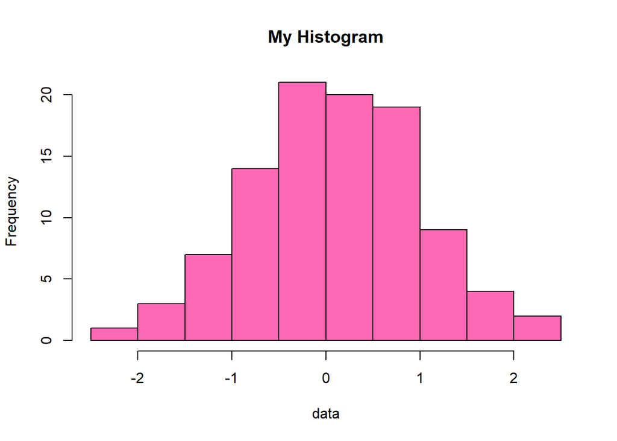

```r
# Simulate random data
set.seed(1)
data <- rnorm(100)

# Plot data
hist(data, main='My Histogram', col='hotpink')
```

## 3 Embed an image

The mosquito photograph below can be found at URL `https://i.imgur.com/ed1sT04.jpg`.

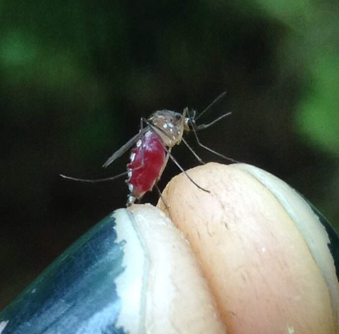

**Hint:** I like to upload images to [imgur](https://imgur.com/) and use the resulting URL to embed them in my R Markdown documents.

**Hint:** You can also use HTML tags in R Markdown documents. For example, to center the image above, you could wrap the embedded image in HTML tags: `<center>![](https://link.to.image)</center>`.